# Name: Riyan Roy

## Student ID: 1009241759

### Course: CHE-1148 - Process Data Analytics

### Assignment-5 Part 1

```python
import pandas as pd
import numpy as np
import matplotlib.pyplot as plt
import seaborn as sns
from sklearn.model_selection import train_test_split
from sklearn.ensemble import RandomForestClassifier
from sklearn.tree import DecisionTreeClassifier, plot_tree
import pandas as pd
# from sklearn.model_selection import GridSearchCV
# pd.options.mode.chained_assignment = None
```

# 1. Loading the dataset: annual_feature_outputs & Using the Best Random Forest Classifier

```python
annual_feature_outputs = pd.read_csv("annual_feature_outputs.csv")
```

```python
# Dropping response from the dataset to store it into a new Dataframe
X = annual_feature_outputs.drop(['response',"customer_id"],axis=1)
y = annual_feature_outputs['response']

X_train_annual, X_test_annual, y_train_annual, y_test_annual = train_test_split(X, y, test_size=1/3, random_state=1148)
```

```python
pd.DataFrame(X_train_annual)
```

|  | 2011_ann_txn_amt_sum | 2012_ann_txn_amt_sum | 2013_ann_txn_amt_sum | 2014_ann_txn_amt_sum | 2015_ann_txn_amt_sum | 2011_ann_txn_amt_ave | 2012_ann_txn_amt_ave | 2013_ann_txn_amt_ave | 2014_ann_txn_amt_ave | 2015_ann_txn_amt_ave | ... | cnt_2014_Thursday | cnt_2014_Tuesday | cnt_2014_Wednesday | cnt_2015_Friday | cnt_2015_Monday | cnt_2015_Saturday | cnt_2015_Sunday | cnt_2015_Thursday | cnt_2015_Tuesday | cnt_2015_Wednesday |
| --- | --- | --- | --- | --- | --- | --- | --- | --- | --- | --- | --- | --- | --- | --- | --- | --- | --- | --- | --- | --- | --- |
| 6826 | 0 | 165 | 99 | 200 | 0 | 0.000000 | 55.000000 | 33.000000 | 66.666667 | 0.0 | ... | 0 | 1 | 1 | 0 | 0 | 0 | 0 | 0 | 0 | 0 |
| 2585 | 82 | 606 | 248 | 514 | 71 | 82.000000 | 75.750000 | 62.000000 | 73.428571 | 71.0 | ... | 1 | 1 | 1 | 0 | 0 | 0 | 0 | 1 | 0 | 0 |
| 2152 | 268 | 428 | 272 | 202 | 101 | 89.333333 | 61.142857 | 90.666667 | 67.333333 | 101.0 | ... | 0 | 1 | 0 | 0 | 1 | 0 | 0 | 0 | 0 | 0 |
| 3418 | 212 | 664 | 256 | 345 | 0 | 53.000000 | 83.000000 | 85.333333 | 86.250000 | 0.0 | ... | 0 | 0 | 1 | 0 | 0 | 0 | 0 | 0 | 0 | 0 |
| 3689 | 146 | 273 | 469 | 290 | 76 | 48.666667 | 68.250000 | 78.166667 | 72.500000 | 76.0 | ... | 1 | 1 | 0 | 0 | 1 | 0 | 0 | 0 | 0 | 0 |
| ... | ... | ... | ... | ... | ... | ... | ... | ... | ... | ... | ... | ... | ... | ... | ... | ... | ... | ... | ... | ... | ... |
| 4477 | 108 | 489 | 777 | 376 | 100 | 54.000000 | 61.125000 | 86.333333 | 62.666667 | 100.0 | ... | 0 | 1 | 1 | 0 | 1 | 0 | 0 | 0 | 0 | 0 |
| 1688 | 214 | 276 | 228 | 269 | 76 | 53.500000 | 55.200000 | 76.000000 | 89.666667 | 76.0 | ... | 1 | 0 | 0 | 0 | 0 | 0 | 1 | 0 | 0 | 0 |
| 5039 | 141 | 42 | 0 | 194 | 28 | 70.500000 | 42.000000 | 0.000000 | 38.800000 | 28.0 | ... | 1 | 0 | 1 | 0 | 0 | 0 | 0 | 0 | 1 | 0 |
| 1097 | 0 | 297 | 319 | 333 | 0 | 0.000000 | 59.400000 | 63.800000 | 66.600000 | 0.0 | ... | 0 | 0 | 1 | 0 | 0 | 0 | 0 | 0 | 0 | 0 |
| 5065 | 19 | 249 | 167 | 46 | 0 | 19.000000 | 49.800000 | 41.750000 | 46.000000 | 0.0 | ... | 0 | 0 | 0 | 0 | 0 | 0 | 0 | 0 | 0 | 0 |

4589 rows × 75 columns

```python
best_rf = RandomForestClassifier(n_estimators=60,max_depth=2,random_state=1148)
```

```python
best_rf = best_rf.fit(X_train_annual,y_train_annual)
importance = best_rf.feature_importances_
indices = np.argsort(importance[::-1])
feature_importance = [(X_train_annual.columns[i],importance[i]) for i in indices]
feature_importance = pd.DataFrame(feature_importance)
feature_importance = feature_importance.rename(columns={0:'Feature',1:"Importance"}).sort_values(by="Importance",ascending=False)
```

```python
# get the top 5 features
top_features = feature_importance.iloc[:5,:]
feature_names = np.array(top_features.loc[:,"Feature"])
```

# 2. Plotting the most important features for the model.

1. 2014_ann_txn_amt_cnt
2. 2013_ann_txn_amt_sum
3. 2014_ann_txn_amt_max
4. 2014_ann_txn_amt_sum
5. 2013_ann_txn_amt_max

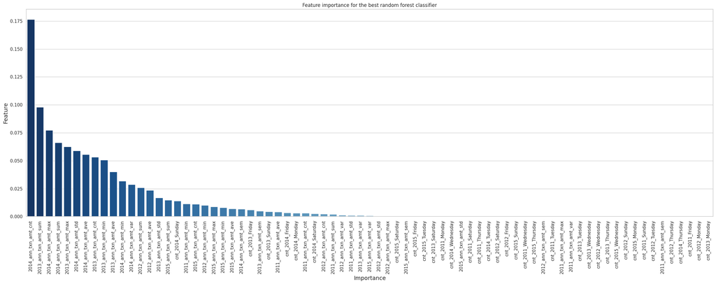

```python
plt.figure(figsize=(25,10))
plt.title("Feature importance for the best random forest classifier")
sns.set(style='whitegrid')
sns.barplot(x='Feature',y='Importance',data=feature_importance,palette="Blues_r")
plt.xlabel("Importance", fontsize=14)
plt.ylabel("Feature", fontsize=14)
plt.xticks(rotation=90)
plt.tight_layout()
```

```python
feature_names
```

```
array(['2014_ann_txn_amt_cnt', '2013_ann_txn_amt_sum',
       '2014_ann_txn_amt_max', '2014_ann_txn_amt_sum',
       '2013_ann_txn_amt_max'], dtype=object)
```

```python
top_features
```

|  | Feature | Importance |
| --- | --- | --- |
| 42 | 2014_ann_txn_amt_cnt | 0.176607 |
| 20 | 2013_ann_txn_amt_sum | 0.098035 |
| 10 | 2014_ann_txn_amt_max | 0.077378 |
| 21 | 2014_ann_txn_amt_sum | 0.066295 |
| 9 | 2013_ann_txn_amt_max | 0.062643 |

```python
# Dataset Containing the first important feature: "2014_ann_txn_amt_cnt"
X_train_1 = pd.DataFrame(X_train_annual.loc[:,feature_names[0]]).reset_index().drop("index",axis=1)
y_train_1 = pd.DataFrame(y_train_annual).reset_index().drop("index",axis=1)

# Dataset Containing the second important feature: "2013_ann_txn_amt_sum"
X_train_2 = pd.DataFrame(X_train_annual.loc[:,feature_names[1]]).reset_index().drop("index",axis=1)
y_train_2 = pd.DataFrame(y_train_annual).reset_index().drop("index",axis=1)

# Dataset Containing the third important feature: "2014_ann_txn_amt_max"
X_train_3 = pd.DataFrame(X_train_annual.loc[:,feature_names[2]]).reset_index().drop("index",axis=1)
y_train_3 = pd.DataFrame(y_train_annual).reset_index().drop("index",axis=1)

# Dataset Containing the fourth important feature: "2013_ann_txn_amt_sum"
X_train_4 = pd.DataFrame(X_train_annual.loc[:,feature_names[3]]).reset_index().drop("index",axis=1)
y_train_4 = pd.DataFrame(y_train_annual).reset_index().drop("index",axis=1)

# Dataset Containing the fifth important feature: "2013_ann_txn_amt_max"
X_train_5 = pd.DataFrame(X_train_annual.loc[:,feature_names[4]]).reset_index().drop("index",axis=1)
y_train_5 = pd.DataFrame(y_train_annual).reset_index().drop("index",axis=1)
```

# 3. Partial Dependency Plots for the five most important features.

The partial dependency plot shows the marginal effect of the features on the the predicted outcome of the best random forest machine learning model. It illustrates how the target variable changes as the feature of interest changes. It is useful for interpreting and explaining the behavior of a model, especially when it comes to understanding how specific features affect the model's predictions.

Here, 0 - Negative Response, 1- Positive Response

## 3.1 PDP for "2014_ann_txn_amt_cnt"

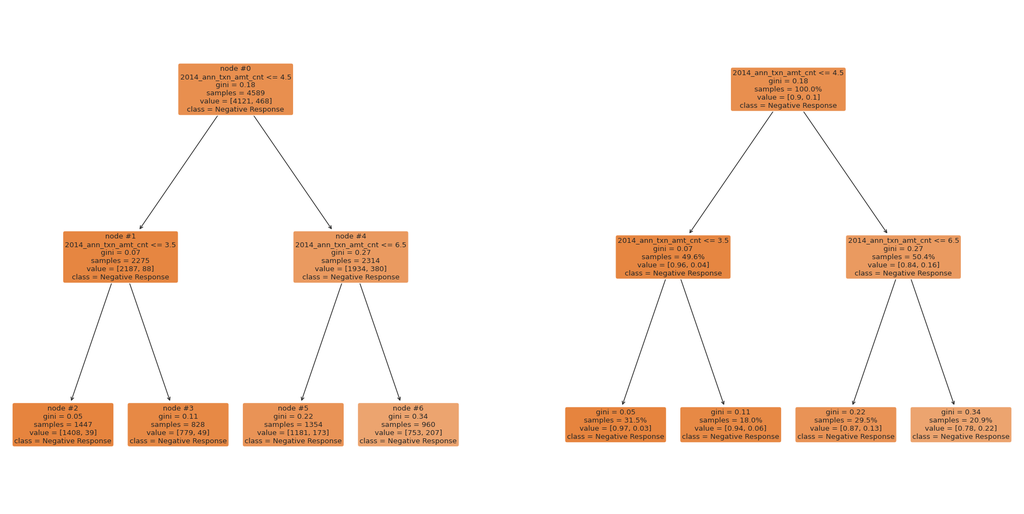

```python
# create a decision tree classifier with maximum depth of 2, minimum samples to split of 2, entropy criterion, and a fixed random state
dt_model_1 = DecisionTreeClassifier(max_depth=2, min_samples_split=2, random_state=1148)

# train the decision tree classifier on the features (X_train_1) and labels (y_train_1) data
estimator_1 = dt_model_1.fit(X_train_1, y_train_1)

# create a new figure for plotting
fig_1 = plt.figure(figsize=(24, 12))

# create a subplot for the first plot, which shows the decision tree with filled nodes and node IDs
fig_1_a = plt.subplot(121)
axs1 = plot_tree(estimator_1, filled=True, feature_names=feature_names, class_names=['Negative Response', 'Positive Response'], rounded=True, precision=2, node_ids=True)

# create a subplot for the second plot, which shows the decision tree with filled nodes and node proportions
fig_1_b = plt.subplot(122)
axs2 = plot_tree(estimator_1, filled=True, feature_names=feature_names, class_names=['Negative Response', 'Positive Response'], rounded=True, precision=2, proportion=True)

# display the plot
plt.show()
```

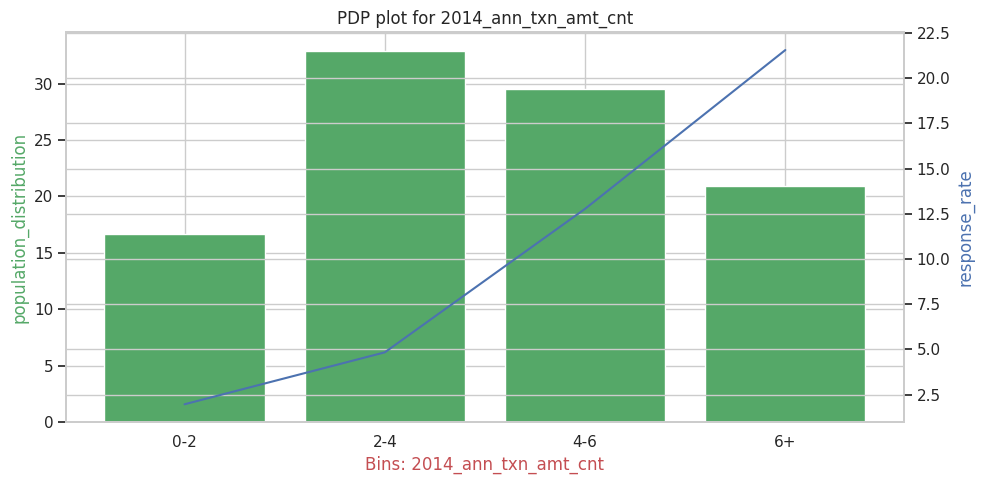

```python
# Initialize empty lists for population distribution and responses for each group
population_distributions = [[] for _ in range(4)]
responses = [[] for _ in range(4)]

# Iterate over data and assign to appropriate group
for i in range(len(X_train_1)):
    feature = X_train_1.loc[i]
    if feature.iloc[0] <= 2:
        group_index = 0
    elif feature.iloc[0] <= 4:
        group_index = 1
    elif feature.iloc[0] <= 6:
        group_index = 2
    else:
        group_index = 3
    population_distributions[group_index].append(feature.iloc[0])
    responses[group_index].append(y_train_1['response'][i])

# Calculate population distribution and response rate for each group
population_distribution_1 = [len(population_distributions[i]) / len(X_train_1) * 100 for i in range(4)]
response_rate_1 = [len([r for r in responses[i] if r == 1]) / len(responses[i]) * 100 for i in range(4)]

# Plot results
fig, ax1 = plt.subplots(figsize=(10, 5))
ax1.set_title("PDP plot for {}".format(feature_names[0]))
ax2 = ax1.twinx()
ax1.bar(['0-2', '2-4', '4-6', '6+'], population_distribution_1, color='g')
ax2.plot(['0-2', '2-4', '4-6', '6+'], response_rate_1, color='b')
ax1.set_xlabel("Bins: {}".format(feature_names[0]), color='r')
ax1.set_ylabel('population_distribution', color='g')
ax2.set_ylabel('response_rate', color='b')
plt.tight_layout()
plt.show()
```

**Conclusion**: The objective of the analysis is to investigate the relationship between the number of transactions made by clients in 2014 and their response to the marketing campaign. The highest response rate of 21% was observed for clients who had made more than 6 transactions in the year 2014, indicating their satisfaction with the product. On the other hand, the response rate was lower for clients with less than 2 transactions or no purchases. Despite of majority of customers having transactions between 2-4, (the response rate was quite low less than 5%), hence its safe to say that customers having transaction more than 6 are bound to provide positive response for the campaign

## 3.2 PDP for "2013_ann_txn_amt_sum"

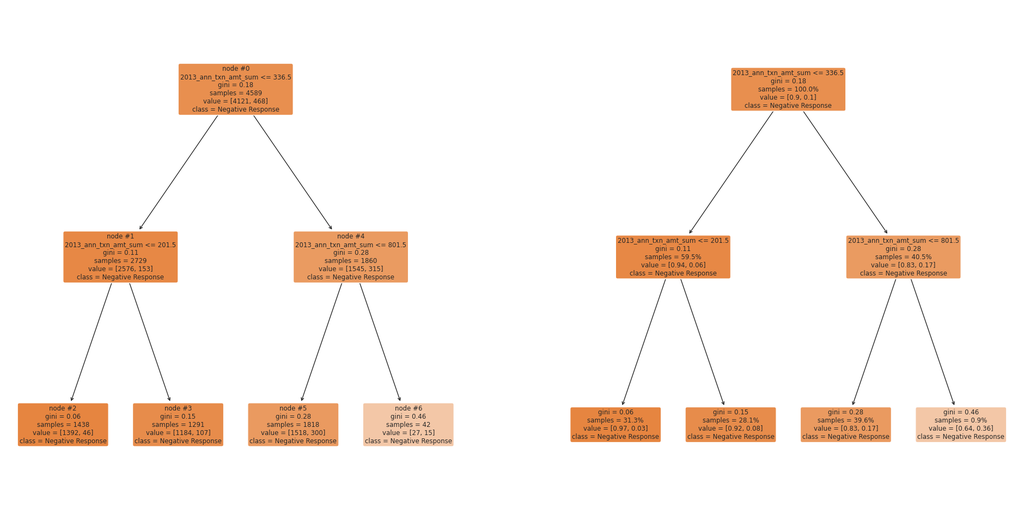

```python
# create a decision tree classifier with maximum depth of 2, minimum samples to split of 2, entropy criterion, and a fixed random state
dt_model_2 = DecisionTreeClassifier(max_depth=2, min_samples_split=2, random_state=1148)

# train the decision tree classifier on the features (X_train_2) and labels (y_train_1) data
estimator_2 = dt_model_2.fit(X_train_2, y_train_2)

# create a new figure for plotting
fig_2 = plt.figure(figsize=(24, 12))

# create a subplot for the first plot, which shows the decision tree with filled nodes and node IDs
fig_2_a = plt.subplot(121)
axs2 = plot_tree(estimator_2, filled=True, feature_names=list(X_train_2.columns), class_names=['Negative Response', 'Positive Response'], rounded=True, precision=2, node_ids=True)

# create a subplot for the second plot, which shows the decision tree with filled nodes and node proportions
fig_2_b = plt.subplot(122)
axs2 = plot_tree(estimator_2, filled=True, feature_names=list(X_train_2.columns), class_names=['Negative Response', 'Positive Response'], rounded=True, precision=2, proportion=True)

# display the plot
plt.show()
```

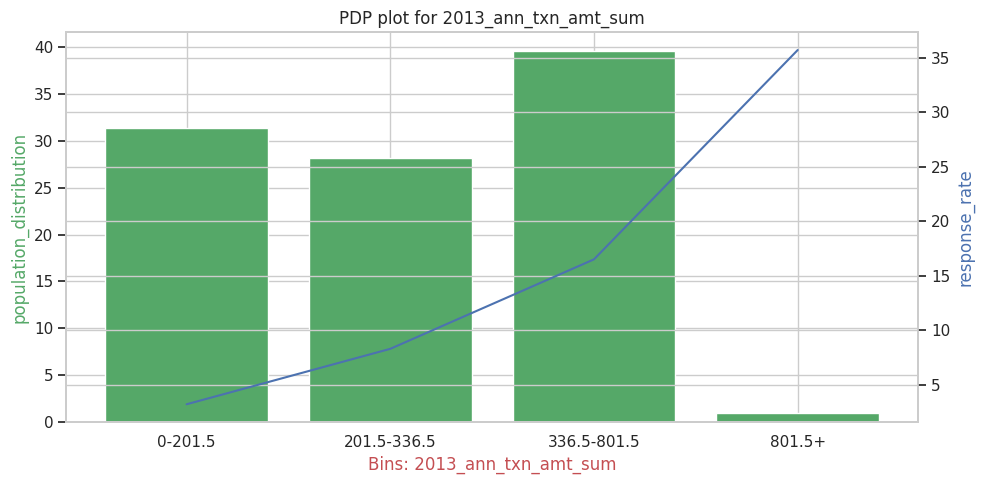

```python
# Initialize empty lists for population distribution and responses for each group
population_distributions = [[] for _ in range(4)]
responses = [[] for _ in range(4)]

# Iterate over data and assign to appropriate group
for i in range(len(X_train_2)):
    feature = X_train_2.loc[i]
    if feature.iloc[0] <= 201.5:
        group_index = 0
    elif feature.iloc[0] <= 336.5:
        group_index = 1
    elif feature.iloc[0] <= 801.5:
        group_index = 2
    else:
        group_index = 3
    population_distributions[group_index].append(feature.iloc[0])
    responses[group_index].append(y_train_2['response'][i])

# Calculate population distribution and response rate for each group
population_distribution_2 = [len(population_distributions[i]) / len(X_train_2) * 100 for i in range(4)]
response_rate_2 = [len([r for r in responses[i] if r == 1]) / len(responses[i]) * 100 for i in range(4)]

# Plot results
fig, ax1 = plt.subplots(figsize=(10, 5))
ax1.set_title("PDP plot for {}".format(feature_names[1]))
ax2 = ax1.twinx()
ax1.bar(['0-201.5', '201.5-336.5', '336.5-801.5', '801.5+'], population_distribution_2, color='g')
ax2.plot(['0-201.5', '201.5-336.5', '336.5-801.5', '801.5+'], response_rate_2, color='b')
ax1.set_xlabel("Bins: {}".format(feature_names[1]), color='r')
ax1.set_ylabel('population_distribution', color='g')
ax2.set_ylabel('response_rate', color='b')
plt.tight_layout()
plt.show()
```

**Conclusion**: The highest response rate of only 36% was observed for clients who had total annual transactions sum more than $$800. The response rate was lowest for clients with the least annual transaction amount (total) of less than $200. The highest population density of the customers had lumpsum transaction amount between $330 and $800, however the response rate was low at around 15%, while the highest response rate was observed for the highest transaction amount of $800+, which had the least population distribution. Therefore, it can be concluded that the customer population having transaction less than $200 would most probably give a negative response, while customers having more than $800 would have a high probability to provide a positive response for the marketing campaign.

## 3.3 PDP for "2014_ann_txn_amt_max"

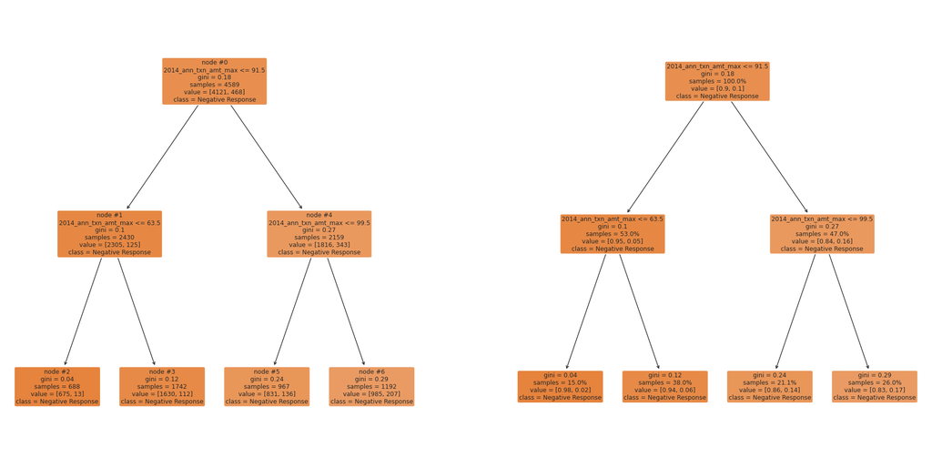

```python
# create a decision tree classifier with maximum depth of 2, minimum samples to split of 2, entropy criterion, and a fixed random state
dt_model_3 = DecisionTreeClassifier(max_depth=2, min_samples_split=2, random_state=1148)

# train the decision tree classifier on the features (X_train_3) and labels (y_train_3) data
estimator_3 = dt_model_3.fit(X_train_3, y_train_3)

# create a new figure for plotting
fig_3 = plt.figure(figsize=(24, 12))

# create a subplot for the first plot, which shows the decision tree with filled nodes and node IDs
fig_3_a = plt.subplot(121)
axs3 = plot_tree(estimator_3, filled=True, feature_names=list(X_train_3.columns), class_names=['Negative Response', 'Positive Response'], rounded=True, precision=2, node_ids=True)

# create a subplot for the second plot, which shows the decision tree with filled nodes and node proportions
fig_3_b = plt.subplot(122)
axs3 = plot_tree(estimator_3, filled=True, feature_names=list(X_train_3.columns), class_names=['Negative Response', 'Positive Response'], rounded=True, precision=2, proportion=True)

# display the plot
plt.show()
```

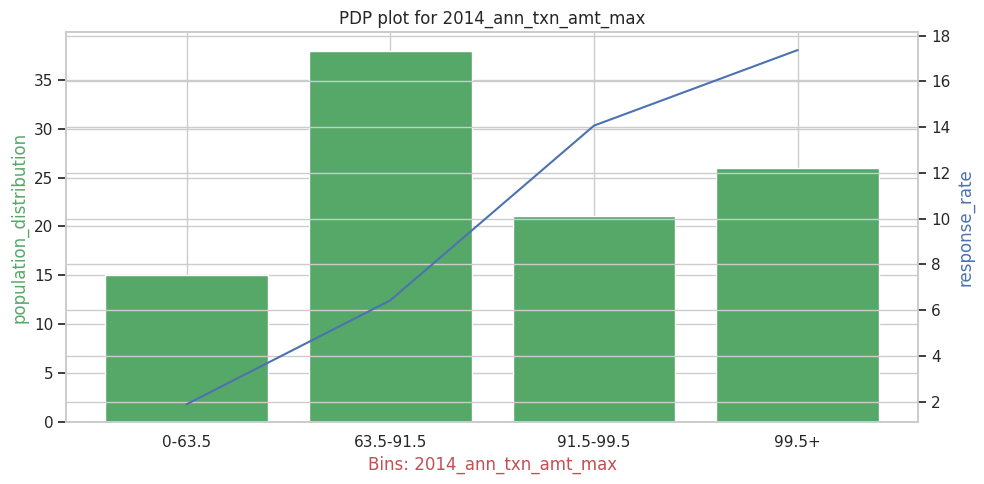

```python
# Initialize empty lists for population distribution and responses for each group
population_distributions = [[] for _ in range(4)]
responses = [[] for _ in range(4)]

# Iterate over data and assign to appropriate group
for i in range(len(X_train_3)):
    feature = X_train_3.loc[i]
    if feature.iloc[0] <= 63.5:
        group_index = 0
    elif feature.iloc[0] <= 91.5:
        group_index = 1
    elif feature.iloc[0] <= 99.5:
        group_index = 2
    else:
        group_index = 3
    population_distributions[group_index].append(feature.iloc[0])
    responses[group_index].append(y_train_3['response'][i])

# Calculate population distribution and response rate for each group
population_distribution_3 = [len(population_distributions[i]) / len(X_train_3) * 100 for i in range(4)]
response_rate_3 = [len([r for r in responses[i] if r == 1]) / len(responses[i]) * 100 for i in range(4)]

# Plot results
fig, ax3 = plt.subplots(figsize=(10, 5))
ax3.set_title("PDP plot for {}".format(feature_names[2]))
ax2 = ax3.twinx()
ax3.bar(['0-63.5', '63.5-91.5', '91.5-99.5', '99.5+'], population_distribution_3, color='g')
ax2.plot(['0-63.5', '63.5-91.5', '91.5-99.5', '99.5+'], response_rate_3, color='b')
ax3.set_xlabel("Bins: {}".format(feature_names[2]), color='r')
ax3.set_ylabel('population_distribution', color='g')
ax2.set_ylabel('response_rate', color='b')
plt.tight_layout()
plt.show()
```

**Conclusion**: The highest response rate of only 17% was observed for clients who had maximum amount per transactions of more than $$99 in 2014. The response rate was lowest for clients with the least maximum amount per transactions of less than $63. The highest population density of the customers had maximum amount per transactions between $63 and $91, however the response rate was low at around 6%, while the lowest response rate was observed for customers having less than $63 of amount per transaction, which had the least population distribution. Therefore, it can be concluded that the customer population having maximum amount per transaction of less than $90 would most probably give a negative response, while customers having more than $90 would have a high probability to provide a positive response for the marketing campaign.

## 3.4 PDP for "2014_ann_txn_amt_sum"

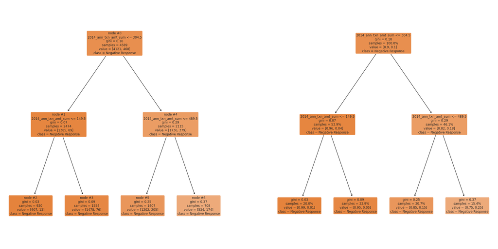

```python
# create a decision tree classifier with maximum depth of 2, minimum samples to split of 2, entropy criterion, and a fixed random state
dt_model_4 = DecisionTreeClassifier(max_depth=2, min_samples_split=2, random_state=1148)

# train the decision tree classifier on the features (X_train_4) and labels (y_train_4) data
estimator_4 = dt_model_4.fit(X_train_4, y_train_4)

# create a new figure for plotting
fig_4 = plt.figure(figsize=(24, 12))

# create a subplot for the first plot, which shows the decision tree with filled nodes and node IDs
fig_4_a = plt.subplot(121)
axs4 = plot_tree(estimator_4, filled=True, feature_names=list(X_train_4.columns), class_names=['Negative Response', 'Positive Response'], rounded=True, precision=2, node_ids=True)

# create a subplot for the second plot, which shows the decision tree with filled nodes and node proportions
fig_4_b = plt.subplot(122)
axs4 = plot_tree(estimator_4, filled=True, feature_names=list(X_train_4.columns), class_names=['Negative Response', 'Positive Response'], rounded=True, precision=2, proportion=True)

# display the plot
plt.show()
```

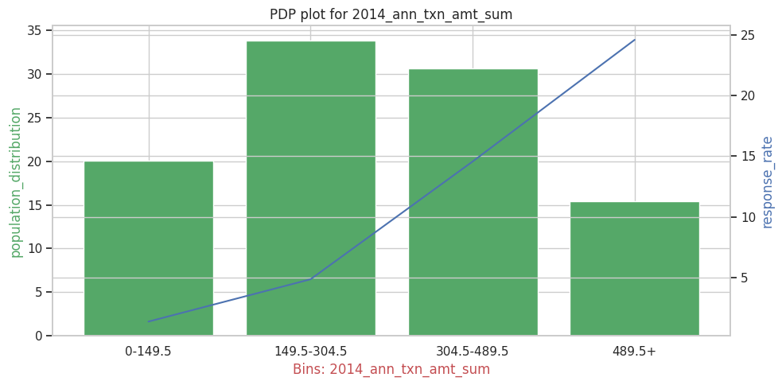

```python
# Initialize empty lists for population distribution and responses for each group
population_distributions = [[] for _ in range(4)]
responses = [[] for _ in range(4)]

# Iterate over data and assign to appropriate group
for i in range(len(X_train_4)):
    feature = X_train_4.loc[i]
    if feature.iloc[0] <= 149.5:
        group_index = 0
    elif feature.iloc[0] <= 304.5:
        group_index = 1
    elif feature.iloc[0] <= 489.5:
        group_index = 2
    else:
        group_index = 3
    population_distributions[group_index].append(feature.iloc[0])
    responses[group_index].append(y_train_4['response'][i])

# Calculate population distribution and response rate for each group
population_distribution_4 = [len(population_distributions[i]) / len(X_train_4) * 100 for i in range(4)]
response_rate_4 = [len([r for r in responses[i] if r == 1]) / len(responses[i]) * 100 for i in range(4)]

# Plot results
fig, ax4 = plt.subplots(figsize=(10, 5))
ax4.set_title("PDP plot for {}".format(feature_names[3]))
ax2 = ax4.twinx()
ax4.bar(['0-149.5', '149.5-304.5', '304.5-489.5', '489.5+'], population_distribution_4, color='g')
ax2.plot(['0-149.5', '149.5-304.5', '304.5-489.5', '489.5+'], response_rate_4, color='b')
ax4.set_xlabel("Bins: {}".format(feature_names[3]), color='r')
ax4.set_ylabel('population_distribution', color='g')
ax2.set_ylabel('response_rate', color='b')
plt.tight_layout()
plt.show()
```

**Conclusion**: The highest response rate of only 25% was observed for clients who had total annual transactions sum more than $$489. The response rate was lowest for clients with the least annual transaction amount (total) of less than $150. The highest population density of the customers had lumpsum transaction amount between $150 and $304.5, however the response rate was low at around 5%, while the highest response rate was observed for the highest transaction amount of $489+, which had the least population distribution. Therefore, it can be concluded that the customer population having transaction less than $300 would most probably give a negative response, while customers having more than $500 would have a high probability to provide a positive response for the marketing campaign.

## 3.5 PDP for "2013_ann_txn_amt_max"

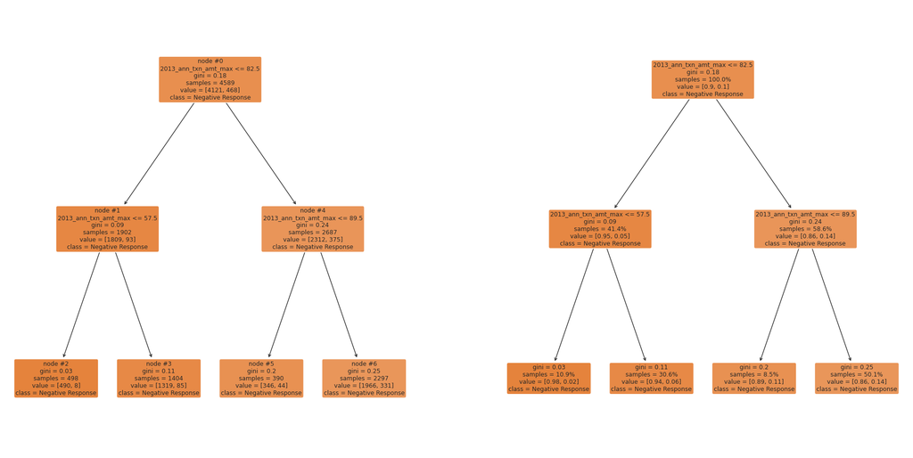

```python
# create a decision tree classifier with maximum depth of 2, minimum samples to split of 2, entropy criterion, and a fixed random state
dt_model_5 = DecisionTreeClassifier(max_depth=2, min_samples_split=2, random_state=1148)

# train the decision tree classifier on the features (X_train_4) and labels (y_train_4) data
estimator_5 = dt_model_5.fit(X_train_5, y_train_5)

# create a new figure for plotting
fig_5 = plt.figure(figsize=(24, 12))

# create a subplot for the first plot, which shows the decision tree with filled nodes and node IDs
fig_5_a = plt.subplot(121)
axs5 = plot_tree(estimator_5, filled=True, feature_names=list(X_train_5.columns), class_names=['Negative Response', 'Positive Response'], rounded=True, precision=2, node_ids=True)

# create a subplot for the second plot, which shows the decision tree with filled nodes and node proportions
fig_5_b = plt.subplot(122)
axs5 = plot_tree(estimator_5, filled=True, feature_names=list(X_train_5.columns), class_names=['Negative Response', 'Positive Response'], rounded=True, precision=2, proportion=True)

# display the plot
plt.show()
```

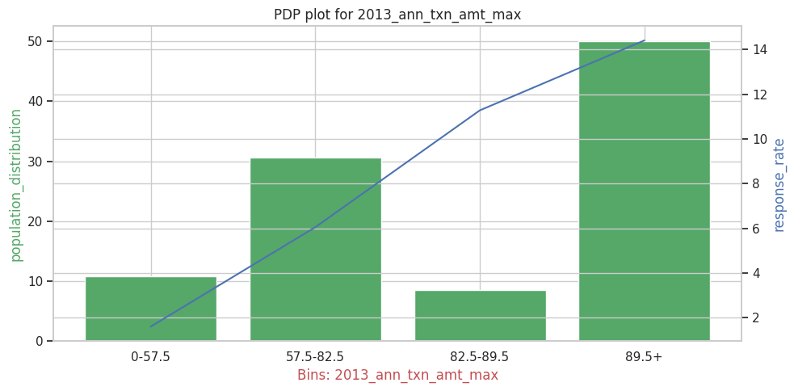

```python
# Initialize empty lists for population distribution and responses for each group
population_distributions = [[] for _ in range(4)]
responses = [[] for _ in range(4)]

# Iterate over data and assign to appropriate group
for i in range(len(X_train_5)):
    feature = X_train_5.loc[i]
    if feature.iloc[0] <= 57.5:
        group_index = 0
    elif feature.iloc[0] <= 82.5:
        group_index = 1
    elif feature.iloc[0] <= 89.5:
        group_index = 2
    else:
        group_index = 3
    population_distributions[group_index].append(feature.iloc[0])
    responses[group_index].append(y_train_5['response'][i])

# Calculate population distribution and response rate for each group
population_distribution_5 = [len(population_distributions[i]) / len(X_train_5) * 100 for i in range(4)]
response_rate_5 = [len([r for r in responses[i] if r == 1]) / len(responses[i]) * 100 for i in range(4)]

# Plot results
fig, ax5 = plt.subplots(figsize=(10, 5))
ax5.set_title("PDP plot for {}".format(feature_names[4]))
ax2 = ax5.twinx()
ax5.bar(['0-57.5', '57.5-82.5', '82.5-89.5', '89.5+'], population_distribution_5, color='g')
ax2.plot(['0-57.5', '57.5-82.5', '82.5-89.5', '89.5+'], response_rate_5, color='b')
ax5.set_xlabel("Bins: {}".format(feature_names[4]), color='r')
ax5.set_ylabel('population_distribution', color='g')
ax2.set_ylabel('response_rate', color='b')
plt.tight_layout()
plt.show()
```

**Conclusion**: The highest response rate of only 14% was observed for clients who had maximum amount per transactions of more than $$89 in 2013. The response rate was lowest at 2% for clients with the least maximum amount per transactions of less than $57.5. The highest population density of the customers had maximum amount per transactions more than $80, while the response rate was also high (more than 10%) when compared with the other categories/population. A good response rate was observed for customers having maximum amount per transaction between $80 and $90, which had the least population distribution. Therefore, it can be concluded that the customer population having maximum amount per transaction of less than $57.5 would most probably give a negative response, while customers having more than $80 would have a high probability to provide a positive response for the marketing campaign.

# 4. Bonus Questions

## 4.1 Correlation between features

```python
corr_matrix = [X_train_annual[i] for i in feature_names]
corr_matrix = pd.DataFrame(corr_matrix).T

import plotly.express as px
corr_matrix = corr_matrix.corr()
px.imshow(corr_matrix,color_continuous_scale='balance',zmin=-1, zmax=1)
```

[interactive chart not shown]

- A high positive value (close to 1.0) indicates a strong positive correlation, indicating that when one variable increases, the other variable also increases.
- A value near 0 (whether positive or negative) indicates the absence of correlation between the two variables, meaning that the variables are independent of each other.
- The cells in the matrix above are represented by various shades of color, with darker shades indicating higher correlation and lighter shades indicating lower correlation.
- The pairs of variables with high correlation are: a) "2014_ann_txn_amt_sum" and "2014_ann_txn_cnt", and b) "2013_ann_txn_amt_sum" and "2013_ann_txn_amt_max".

## 4.2 Partial Dependency of all features (Response rate v/s Population Distribution)

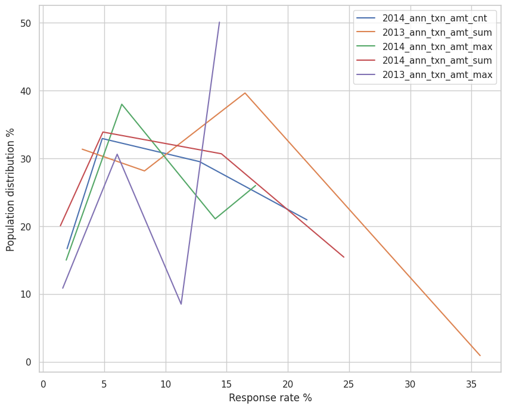

```python
plt.rcParams["figure.figsize"] = (10,8)
l1 = plt.plot(response_rate_1, population_distribution_1, label = feature_names[0])
l2 = plt.plot(response_rate_2, population_distribution_2, label = feature_names[1])
l3 = plt.plot(response_rate_3, population_distribution_3, label = feature_names[2])
l4 = plt.plot(response_rate_4, population_distribution_4, label = feature_names[3])
l5 = plt.plot(response_rate_5, population_distribution_5, label = feature_names[4])
plt.xlabel('Response rate %')
plt.ylabel('Population distribution %')
plt.legend(feature_names)
```

## 4.3 Partial Dependency Display (continuous plot)

[figure not shown]

[figure not shown]

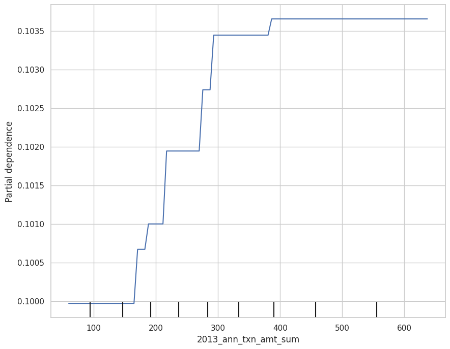

[figure not shown]

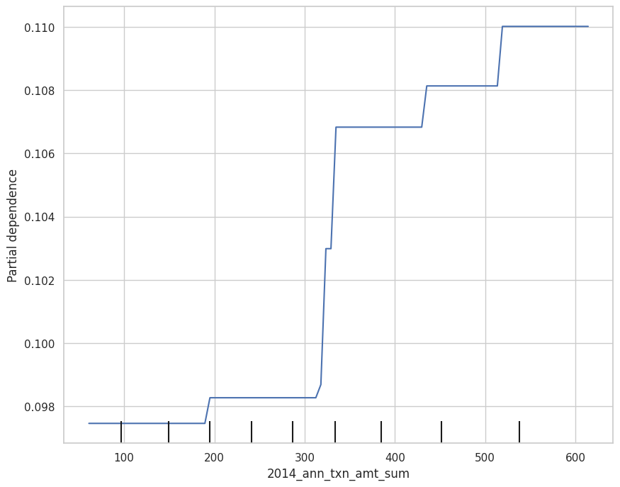

[figure not shown]

```python
from sklearn.inspection import PartialDependenceDisplay

# generate partial dependence plots for each of the top 5 features
fig, axs = plt.subplots(nrows=5, ncols=1, figsize=(10, 30))
for i, feature in enumerate(top_features['Feature']):
    display = PartialDependenceDisplay.from_estimator(
        estimator=best_rf,
        X=X_train_annual,
        features=[i],
        feature_names=feature_names,
        n_jobs=-1,
        grid_resolution=100
    )
    display.plot(ax=axs[i])
    axs[i].set_xlabel(feature, fontsize=16)
    axs[i].set_ylabel('Population distribution (%)', fontsize=16)
    axs[i].twinx().set_ylabel('Response rate (%)', fontsize=16)
plt.tight_layout()
plt.show()
```